# Animal welfare

Phil Gee, Andy Wills

## Before you start…

Before starting this exercise, you should have completed **all** the relevant Absolute Beginners’, Parts 1 & 2 worksheets. Each section below indicates which of the earlier worksheets are relevant.

## Getting the data into R

**Relevant worksheet:** Intro to RStudio

You and your partner must first complete the behaviour coding exercise. You’ll then get a CSV file that contains both your ratings.

Once you have your CSV file, open a project on RStudio Server for this analysis, create a script file, and upload your CSV to your project.

**Plymouth University students**: Create/open your project named `psyc416`; within that create a script file called `lions.R`. Enter all commands into that script and run them from there.

## Exploring your data

### Load

**Relevant worksheet:** Exploring data

Load the *tidyverse* package, and load your data.

```r
# Animal welfare
# Load tidyverse
library(tidyverse)
# Load data into 'animals'
animals <- read_csv("animals.csv")
```

**Note**: Everyone’s CSV file will have a different name. In the example above, you’ll need to replace `animals.csv` with the name of your personal CSV file.

### Inspect

Look at the data by clicking on it in the *Environment* tab in RStudio. Each row is one time point in the video you coded. Here’s what each of the columns in the data set contain:

| Column | Description | Values |
| --- | --- | --- |
| time | Time point. | 1 - 10 |
| period | How long before feeding time? (in minutes). | 10 or 180 |
| behav.r1 | Rater 1’s coding of the animal’s behaviour at each time point. | In the example file, you’ll find: “pacing”, “sleeping”, “standing”, “lying”, “running”. Your codes may be different. |
| behav.r2 | Rater 2’s coding of the animal’s behaviour at each time point. | as above. |
| loc.r1 | Rater 1’s coding of the animal’s location at each time point. | In the example file, you’ll find: “zone_1”, “zone_2”, “zone_3”, “zone_4”. Your codes may be different. |
| loc.r2 | Rater 2’s coding of the animal’s location at each time point. | as above. |

## Percentage agreement

**Relevant worksheet:** Inter-rater reliability

To what extent did you and your workshop partner agree on how each behaviour should be coded? As we covered in the *inter-rater reliability* worksheet, to look at this, we first have to `select` the relevant columns of the data frame. For example, to look at inter-rater reliability for the *behaviour* category, we select:

```r
# Select columns; insert into 'behav'
behav <- animals %>% select(behav.r1, behav.r2)
```

We can now use the `agree` command to work out percentage agreement:

```r
# Load inter-rater-reliability package
library(irr)
# Calculate percentage agreement
agree(behav)
```

```
 Percentage agreement (Tolerance=0)

 Subjects = 20
   Raters = 2
  %-agree = 70
```

**NOTE**: If you get an error here, type `install.packages("irr")`, wait for the package to finish installing, and try again.

The key result here is `%-agree`, which is your percentage agreement. The term `Subjects` here is a bit misleading, it doesn’t mean the number of animals you observed (this data file contains your ratings of one animal), it means the number of time points you recorded an observation for.

**Enter the percentage agreement for your behaviour and location codings into PsycEL**.

## Cohen’s kappa

**Relevant worksheet:** Inter-rater reliability

One problem with the *percentage agreement* measure is that people will sometimes agree purely by chance. Jacob Cohen thought it would be much neater if we could have a measure of agreement where zero always meant the level of agreement expected by chance, and 1 always meant perfect agreement. To calculate his measure, Cohen’s kappa, in R we use the command `kappa2`:

```r
# Calculate Cohen's Kappa
kappa2(behav)
```

```
 Cohen's Kappa for 2 Raters (Weights: unweighted)

 Subjects = 20
   Raters = 2
    Kappa = 0.559

        z = 4.17
  p-value = 3.1e-05
```

**Enter the Cohen’s kappa values for your behaviour and location codings into PsycEL.**

There are some words that psychologists sometimes use to describe the level of agreement between raters, based on the value of kappa they get. These descriptions are listed in the inter-rater reliability worksheet, in the section “Describing Cohen’s kappa”.

**On PsycEL, select the correct term to describe the kappa values for your behaviour and location codings.**

If either of those descriptions are ‘moderate’ or lower, reflect on why that might be. For example, is there a problem with the definitions of the behavioural categories you used? What else might have caused the lack of agreement?

**Write a few sentences into PsycEL summarizing your reflections.**

## Behaviour and feeding time

**Relevant worksheet:** Relationships

Does the animal behave differently when it’s close to feeding time? To look at this, we need to calculate the frequency of each behaviour at our two time periods (10 minutes before feeding, and 180 minutes before feeding). You can use the `table` command we learned in the *Relationships* worksheet to do this, but you’re going to have to choose which behaviour, and which of your two raters, to look at. That’s because it’s likely you will have had at least a few disagreements. But if both of you were looking at the same behaviour, how can we decide who was ‘right’? There are a few possible solutions, but for now we will take the simplest: flip a coin to decide which of your raters’ data you will use.

If you choose “behaviour” and rater 2, the commands would be:

```r
# Create contingency table for 'period' by 'behav.r2'
cont <- table(animals$period, animals$behav.r2)
# Display contingency table
cont
```

```
      lying pacing sleeping standing
  10      3      1        5        1
  180     2      1        6        1
```

### Explanation of command

What you have just done here, as we covered in the relationships worksheet, is to convert your *data frame*, called `animals`, into a *contingency table*, called `cont`. This contingency table shows how often each behaviour occurs at each time period. Recall that `table(rows, columns)` is the command used in R for producing contingency tables. We replace the word `rows` with the name of the variable we want to appear on the rows of the table, and we replace the word `columns` with the name of the variable we want to appear in the columns of the table.

### Bar chart

**Relevant worksheet:** Face recognition

To visualize the relationship between behaviour and feeding time, we’re going to use a bar chart. We covered bar charts in the *Face recognition* worksheet; here we’re going to extend that example to create a bar chart that shows our two different time periods on the same axes.

```r
# Turn contingency table into a data frame, 'df'
df <- data.frame(cont)
# Name the columns of the data frame
colnames(df) <- c("Period", "Behaviour", "Frequency")
# Display a bar chart of 'Frequency' by 'Behaviour', grouping by 'Period'
df %>% ggplot(aes(x = Behaviour, y = Frequency, fill = Period)) + geom_col(position = "dodge")
```

### Explanation of command

This graph command goes a bit beyond what we’ve covered in previous worksheets, so here’s an explanation of how the new bits work:

`df <- data.frame(cont)` - A *data frame* is the standard way R stores data (e.g. `animals` is a data frame). The `ggplot` commands expects to get a data frame, and gets upset if it gets something else, like a contingency table. So, the first thing we do is make a data frame version of `cont` (our contingency table), and give it a name (`df` in this case).

`geom_col(position="dodge")` - As before, `geom_col` is the command for a “column” plot (aka. a bar chart). The new part here is `position="dodge"`; this tells `ggplot` that you want the two different colours of bars to be placed side-by-side, rather than directly on top of each other (i.e. you want them to “dodge” each other).

### Describing your results

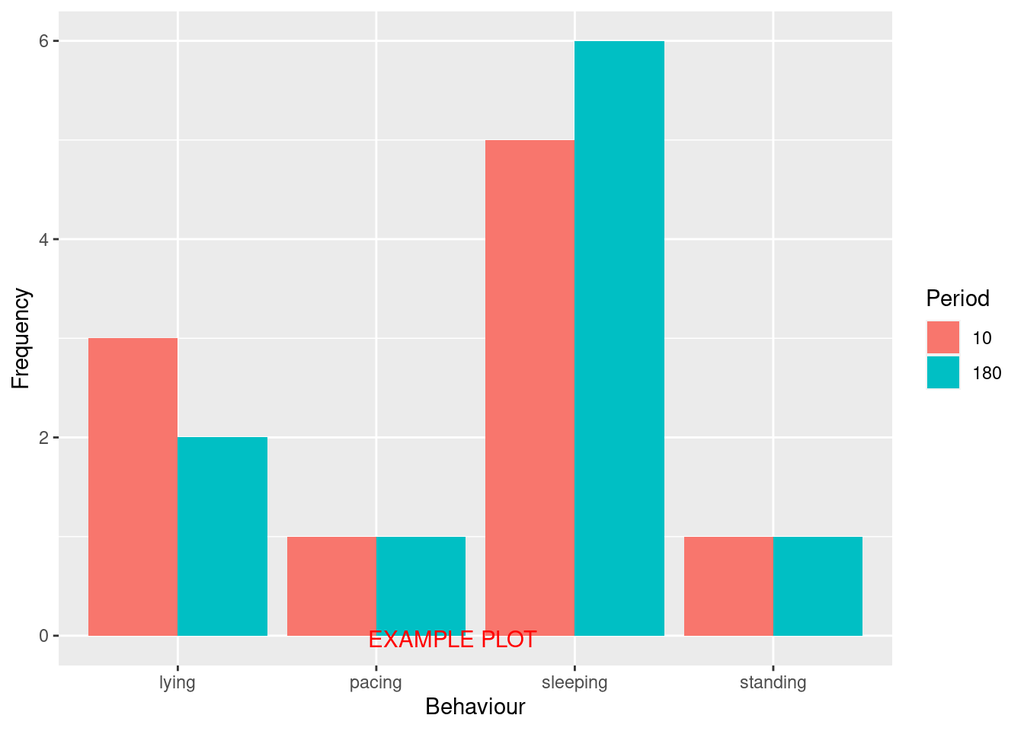

In the above example graph, we can see that the animal was pacing and standing as often in the two time periods, but was lying slightly more 10 minutes before feeding time than 180 minutes before feeding time, and sleeping slightly more 180 minutes before feeding time than 10 minutes before. What do your data show? Did proximity to feeding time have an effect on behaviour? If so, which behaviours were most affected?

**Enter a few sentences into PsycEL describing what your data show.**

### Uploading your graph

1. Export your graph, using the *Export* icon on RStudio’s *Plots* window, and selecting “Save as image…”. Give it a meaningful file name (e.g. “feed-time”) and click ‘Save’.
2. Download your graph from RStudio server - see these instructions for a reminder of how to do this.
3. **Upload your graph to PsycEL** (see the PsychEL activity for instructions of how to do this).

This material is distributed under a [Creative Commons](https://creativecommons.org/) licence. CC-BY-SA 4.0..